# SETUP

Author

Affiliation

Dr. Debasish Mukherjee

Bioinformatics Core Facility CECAD

Published

November 21, 2025

Welcome to the **R and Reproducibility course setup**. In this brief guide, you’ll prepare your system with the tools needed for writing reproducible code, managing projects, and ensuring your analyses can be reliably shared and repeated. Proper setup is the foundation of good scientific practice, so please take a moment to complete each step carefully.

To get started, go through the initial steps below and run **the setup script** and verify that everything installs correctly. If you encounter any issues, let us know so we can help you troubleshoot.

## Github Account Setup

Use your email to create an account at [GitHub](https://github.com)

## Personal access tokens

- [Verify your email address](https://docs.github.com/en/account-and-profile/setting-up-and-managing-your-personal-account-on-github/managing-email-preferences/verifying-your-email-address), if it hasn’t been verified yet.
- Login to your account on GitHub.
- In the upper-right corner of any page on GitHub, click your profile picture, then click **Settings**.

[figure not shown]

- In the left sidebar, click **Developer settings**.

[figure not shown]

- In the left sidebar, under **Personal access tokens**, click **Tokens (classic)**.

[figure not shown]

- Click **Generate new token** and choose **Generate new token (classic)**.

[figure not shown]

- Give your token a descriptive name, select an expiration period, and select the scopes or permissions you’d like to grant this token. For typical use with Git, you might want to select `repo` , `user` and `workflow`.

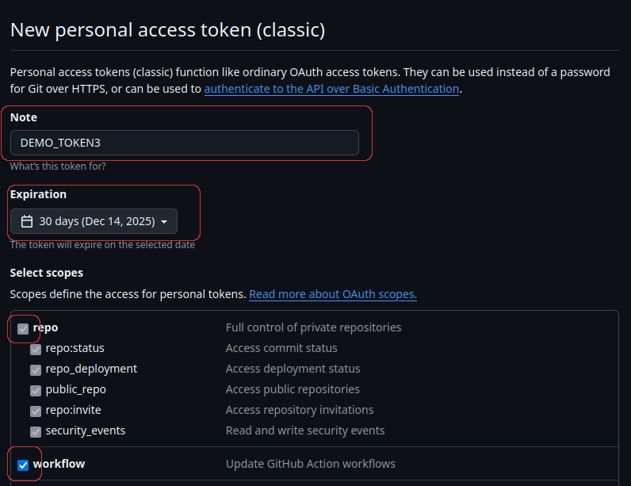

- Click **Generate token** at the bottom of the page. Copy the generated token and store it securely. You won’t be able to see it again!

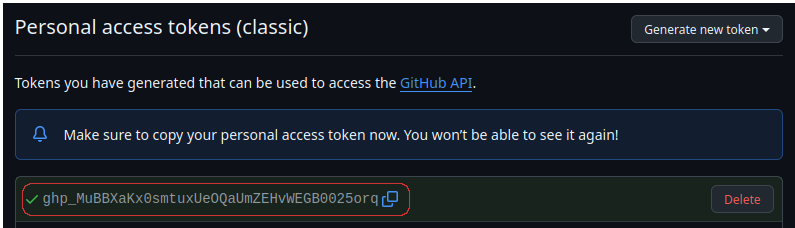

## Setup Git with RStudio

- Visit [Advanced R-course 2025](https://github.com/CECADBioinformaticsCoreFacility/Advanced_R_course_2025) and download `setup_rnaseq_reproducibility.R` script to your local machine and put it in a desired location where you want to create the directory for the course.
- Open RStudio, navigate to the path where the `setup_rnaseq_reproducibility.R` script is. **Make sure you are not within a active R Project**. Now run the script as a whole in the `Console` tab. This will install required packages and configure Git with your GitHub credentials.

```r
source("setup_rnaseq_reproducibility.R")
```

- After some packages installation he script will show : **“! Is it ok to commit them?”** Answer with the number that shows affirmation (i.e. I agree/Yes/Yeah/Definitely …) and hit **Enter**.

[figure not shown]

- Next it will ask for the Personal access tokens(PAT) you created earlier. Paste it in the console and hit **Enter**.
- After the script finishes, restart RStudio to ensure all changes take effect.
- This will create a appropriate directory structure locally for RNA-Seq analysis and initialize a Git repository with a `.gitignore` file tailored for RNA-Seq projects as well as create a GitHub repository.

## Issues

### System Library Dependencies

If there is any missing system library dependencies, you may see error messages during package installation. Please install the required system libraries using your operating system’s package manager. For example, on Ubuntu, you can use `apt-get` to install missing libraries.

Then Delete the “rnaseq_ProjectName” folder created by the script and re-run the script again.